# Merge CAGE and RNA, label clusters and genes

Dan Lu

2/19/19

This version (1) split all CAGE that fall within coding genes to Bcc or Hcc, the only ‘neither’ clusters are those with log2FC > 4 but padj too big for Hcc. (2) only count genes that are expressed in RNA and overlap with expressed CAGE (made it in rlog_all)

**Bcc: CAGE not very up in HS72 (log2FC of CAGE < 4)** Note that CAGE clusters is filtered in the CAGEr step by counts > 50. So just used that as the ON cut for bam, aka any clusters built by CAGEr are ON.  
Note that CAGE raw count threshold 90 is the same as cutting rlog bam < 5, in the current version of CAGEr threshold is 50, close to rlog bam < 4. so there is no cluster with bam rlog and HS72 rlog both < 4.  
**Hcc: CAGE very up in HS72 (log2FC of CAGE >= 4)**  
**genes: Bcc_genes, Hcc_genes, both_genes and none

```r
number_of_spgn_genes=1155 # from 3.2 spgn
off_cut_CAGE=0 # rlog counts, just do a basic filter to remove those that have 1 replicate too small
log2FoldChange_cut_cage=4
qval_cut=0.001
```

# merge RNA and CAGE rlog counts

### load RNA and CAGE rlog transformed counts, and take average

Note this time too lowly expressed genes were filtered out in DE

```r
RNA_rlog <- read.delim("DE_results_rlog_RNA_all.txt", header=T, stringsAsFactors=FALSE) %>% mutate(bam_RNA=(SHS.1.1.HS0hr+SHS.2.1.HS0hr)/2, HS48_RNA=(SHS.1.2.HS48hr+SHS.2.2.HS48hr)/2, HS72_RNA=(SHS.1.3.HS72hr+SHS.2.3.HS72hr)/2, Sa_RNA=(SHS.1.8.Sa+SHS.2.8.Sa)/2, Aly_RNA=(SHS.1.9.Aly+SHS.2.9.Aly)/2 ) #%>% select(X, bam_RNA:Aly_RNA)


CAGE_rlog <- read.delim("DE_normalized_counts_rlog_CAGE_BH_up500_5utr_CDS.txt", stringsAsFactors=FALSE) %>% mutate(bam_CAGE = (B1 + B2)/2, HS72_CAGE=(H1+H2)/2) #%>% select(X, bam_CAGE, HS72_CAGE)
```

### load RNA gene_id to CAGE consensus cluster conversion

** note the mapping here is each gene will have multiple TSSup500, 5utr, and CDS, and each of wich can have multiple CAGE cc** The purpose of this table is just to map gene with cc and count how many cc per gene. So remove other info from the beginning.

```r
rcc <- read.delim("BDGP6_coding_up500_5utr_CDS_intersect_consensusCluster_0.4ol.txt", stringsAsFactors=FALSE, header = F) %>% select(V4, V10) %>% unique() # each gene have multiple sections/rows (exons, 5'utr etc.)

nrow(rcc)
```

```
## [1] 14254
```

### merge RNA and CAGE normalized counts

** these are the genes that are expressed! **

```r
rlog_all = inner_join(RNA_rlog, rcc, by=c("X"="V4")) %>% inner_join(CAGE_rlog, by=c("V10"="X"))

names(rlog_all)
```

```
##  [1] "X"              "SHS.1.1.HS0hr"  "SHS.1.2.HS48hr" "SHS.1.3.HS72hr"
##  [5] "SHS.1.8.Sa"     "SHS.1.9.Aly"    "SHS.2.1.HS0hr"  "SHS.2.2.HS48hr"
##  [9] "SHS.2.3.HS72hr" "SHS.2.8.Sa"     "SHS.2.9.Aly"    "bam_RNA"
## [13] "HS48_RNA"       "HS72_RNA"       "Sa_RNA"         "Aly_RNA"
## [17] "V10"            "B1"             "B2"             "H1"
## [21] "H2"             "bam_CAGE"       "HS72_CAGE"
```

```r
table(complete.cases(rlog_all))
```

```
##
##  TRUE
## 13752
```

```r
sum(!complete.cases(rlog_all))
```

```
## [1] 0
```

```r
#write.table(rlog_all, "BDGP6_coding_up500_5utr_CDS_RNA_CAGE_rlog.txt", quote=F, sep="\t", row.names = F, col.names = T)
#write.table(rlog_all, "temp_rlog.txt", quote=F, sep="\t", row.names = F, col.names = T)
```

```r
print(paste0("number of testis expressed coding genes: ", nrow(RNA_rlog)))
```

```
## [1] "number of testis expressed coding genes: 12209"
```

```r
print(paste0("number of CAGE clusters fall within coding genes: ", nrow(unique(select(rcc,V10)))))
```

```
## [1] "number of CAGE clusters fall within coding genes: 13882"
```

```r
print(paste0("number of all coding genes with CAGE intersect: ", nrow(unique(select(rcc,V4)))))
```

```
## [1] "number of all coding genes with CAGE intersect: 9681"
```

```r
print(paste0("number of testis expressed genes with CAGE intersect: ", nrow(unique(select(rlog_all,X)))))
```

```
## [1] "number of testis expressed genes with CAGE intersect: 9371"
```

```r
#print(paste0("number of CAGE clusters fall within testis expressed genes: ", nrow(unique(select(rlog_all,V10)))))
```

# define Bcc Hcc with rlog and CAGE DE

**here counts all CAGE that is expressed and fall within coding regions (not neccessarily expressed in testis RNA)**

### load DE for CAGE

Note the CAGE clusters for DE analysis were already filtered to only contain those fall within genes

```r
CAGE_DE <- read.delim("DE_results_all_CAGE_BH_up500_5utr_CDS.txt", stringsAsFactors=FALSE)
nrow(unique(select(CAGE_DE, X)))
```

```
## [1] 13882
```

### Bcc: CAGE on in bam (rlog >= cutoff)

```r
Bcc_on = filter(CAGE_rlog, B1 >= off_cut_CAGE & B2 >= off_cut_CAGE) %>% rename(V10=X) %>% select(V10) %>% unique()

Bcc_not_up = filter(CAGE_DE, log2FoldChange < log2FoldChange_cut_cage)%>% select(X) %>% unique()

Bcc=inner_join(Bcc_on, Bcc_not_up, by=c("V10"= "X")) %>% unique() %>% mutate(cc_type="Bcc")

table(complete.cases(Bcc))
```

```
##
##  TRUE
## 10111
```

### Hcc: CAGE very up in HS72 (log2FC of CAGE >= cutoff)

```r
Hcc = filter(CAGE_DE, log2FoldChange >= log2FoldChange_cut_cage & padj < qval_cut ) %>% select(X) %>% rename(V10=X) %>% unique() %>% mutate(cc_type="Hcc")
```

### is there a shift

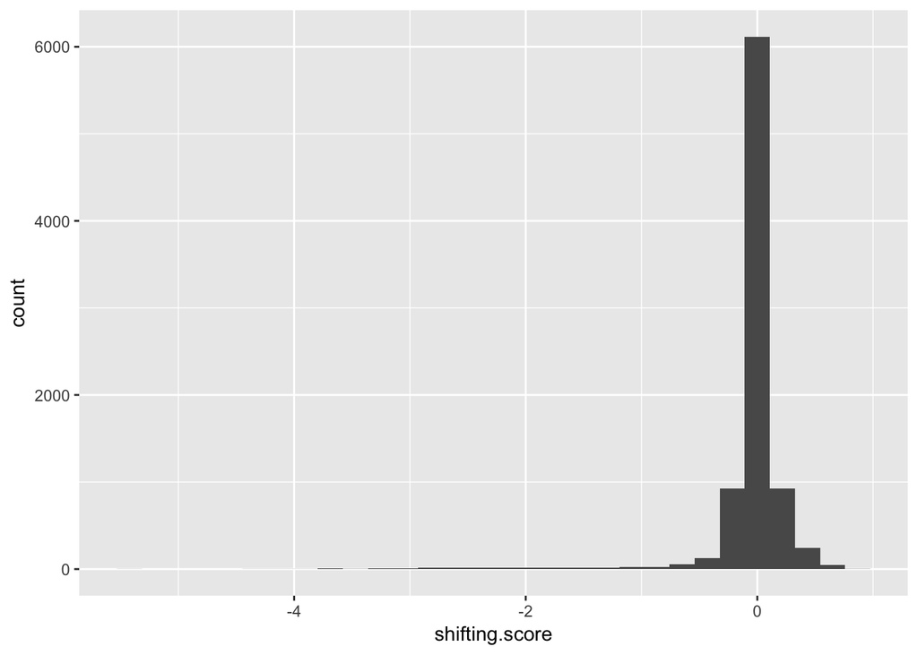

```r
shift <- read.delim("~/Dropbox/z-seq analysis/18-0702 CAGE/14.redo_Q255_filter/shifting_promoters_xbam_yHS72.txt", stringsAsFactors=FALSE)

ggplot(shift) + geom_histogram(aes(shifting.score))
```

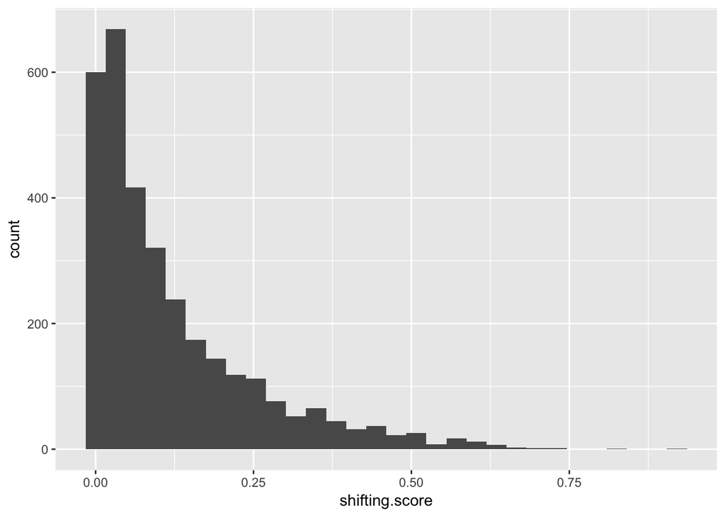

```r
shift %>% filter(shifting.score>0) %>% ggplot() + geom_histogram(aes(shifting.score))
```

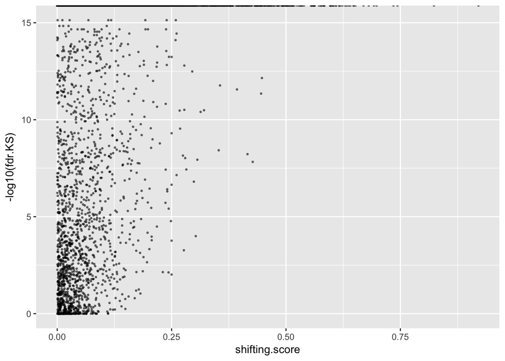

```r
shift %>% filter(shifting.score>0) %>% ggplot() + geom_point(aes(shifting.score, -log10(fdr.KS)), size=0.5, alpha=0.5)
```

```r
shift %<>% filter(shifting.score > 0 & fdr.KS < 0.01) %>% mutate(is.shift=1) %>% select(consensus.cluster, is.shift)

shift$consensus.cluster=paste0("cluster",shift$consensus.cluster)
```

### label clusters as Bcc/Hcc

```r
allcc=bind_rows(Bcc, Hcc) %>% left_join(shift, by=c("V10"="consensus.cluster"))  %>% mutate(is.shift = ifelse(is.na(is.shift), 0, is.shift))
nrow(allcc) #
```

```
## [1] 13879
```

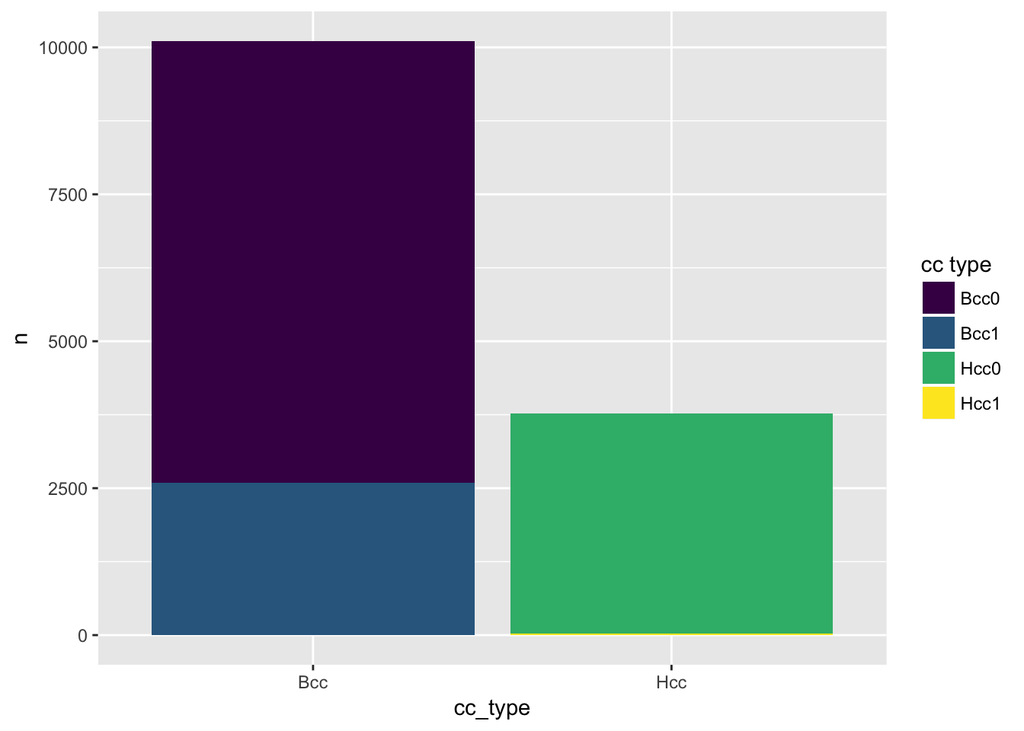

```r
allcc %>%
   count(cc_type, is.shift) %>% mutate(super_label=paste0(cc_type, is.shift)) %>%
  mutate(is_shift = factor(is.shift)) %>%
  ggplot(aes(x = cc_type, y = n, fill = super_label)) +
  geom_bar(stat = "identity") + scale_fill_manual("cc type", values = viridis(4))
```

```r
table(complete.cases(allcc))
```

```
##
##  TRUE
## 13879
```

```r
write.table(allcc, "BDGP6_coding_up500_5utr_CDS_cluster_cctype.txt", sep="\t", quote=F, col.names = T, row.names = F)
```

# define gene types by Bcc/Hcc

**here only count genes that are expressed in testis (RNA_rlog) and have CAGE clusters (rlog_all)**

### match CAGE clusters to gene

```r
gcc = select(rlog_all, X, V10) %>% unique() %>% inner_join(allcc, by="V10")

# full_join(allcc, by="V10") %>% mutate(cc_type = ifelse(is.na(cc_type), "neither", cc_type)) %>% mutate(is.shift = ifelse(is.na(is.shift), 0, is.shift))

nrow(unique(select(gcc, X)))
```

```
## [1] 9371
```

### label genes as Bcc only, Hcc only or both

```r
cc_count = gcc %>% select(X, V10) %>% unique() %>%  group_by(X) %>% summarise(n_cc=n())

Hcc_gene=filter(gcc, cc_type=="Hcc") %>% select(X, cc_type) %>% unique()
Bcc_gene=filter(gcc, cc_type=="Bcc") %>% select(X, cc_type) %>% unique()

both_gene=inner_join(Hcc_gene, Bcc_gene, by="X") %>% mutate(cc_type="both_gene") %>% select(X, cc_type)
Hcc_only_gene=anti_join(Hcc_gene,  Bcc_gene, by="X") %>% mutate(cc_type="Hcc_gene")
Bcc_only_gene=anti_join(Bcc_gene,  Hcc_gene, by="X") %>% mutate(cc_type="Bcc_gene")
all_gene=bind_rows(Hcc_only_gene,Bcc_only_gene,both_gene)

table(complete.cases(all_gene))
```

```
##
## TRUE
## 9371
```

```r
# check to see the numbers match (splitting and merging was done correctly)
nrow(cc_count)
```

```
## [1] 9371
```

```r
nrow(both_gene) + nrow(Hcc_only_gene) + nrow(Bcc_only_gene)
```

```
## [1] 9371
```

```r
a=nrow(cc_count)- (nrow(both_gene) + nrow(Hcc_only_gene) + nrow(Bcc_only_gene))
print(paste0("number of genes with only clusters that are neither Bcc or Hcc",a))
```

```
## [1] "number of genes with only clusters that are neither Bcc or Hcc0"
```

```r
cc_count %<>% left_join(all_gene) %>% rename(gene_cc_type=cc_type) %>% mutate(gene_cc_type = ifelse(is.na(gene_cc_type), "none", gene_cc_type))
table(complete.cases(cc_count))
```

```
##
## TRUE
## 9371
```

```r
write.table(cc_count, "BDGP6_coding_up500_5utr_CDS_gene_cctype.txt", sep="\t", quote=F, col.names = T, row.names = F)
```

# plot how many Bcc/Hcc each gene has

### all genes

```r
kk = cc_count %>% group_by(gene_cc_type) %>% count()
print(kk)
```

```
## # A tibble: 3 x 2
## # Groups:   gene_cc_type [3]
##   gene_cc_type     n
##   <chr>        <int>
## 1 Bcc_gene      6300
## 2 both_gene     1230
## 3 Hcc_gene      1841
```

```r
# kk %<>% add_row(gene_cc_type="spgn", n=number_of_spgn_genes) %>% add_row(gene_cc_type="others", n=kk[1,1]-number_of_spgn_genes)
# can't add rows to grouped data frames...

kk2=data_frame(gene_label_type=c("4.genes with alternative promoters", "3.upregulated genes", "1.downregulated genes","2.others"),  n=c(as.integer(kk[kk$gene_cc_type=="both_gene","n"]),  as.integer(kk[kk$gene_cc_type=="Hcc_gene","n"]), number_of_spgn_genes,  as.integer(kk[kk$gene_cc_type=="Bcc_gene","n"])-number_of_spgn_genes))
print(kk2)
```

```
## # A tibble: 4 x 2
##   gene_label_type                        n
##   <chr>                              <dbl>
## 1 4.genes with alternative promoters  1230
## 2 3.upregulated genes                 1841
## 3 1.downregulated genes               1155
## 4 2.others                            5145
```

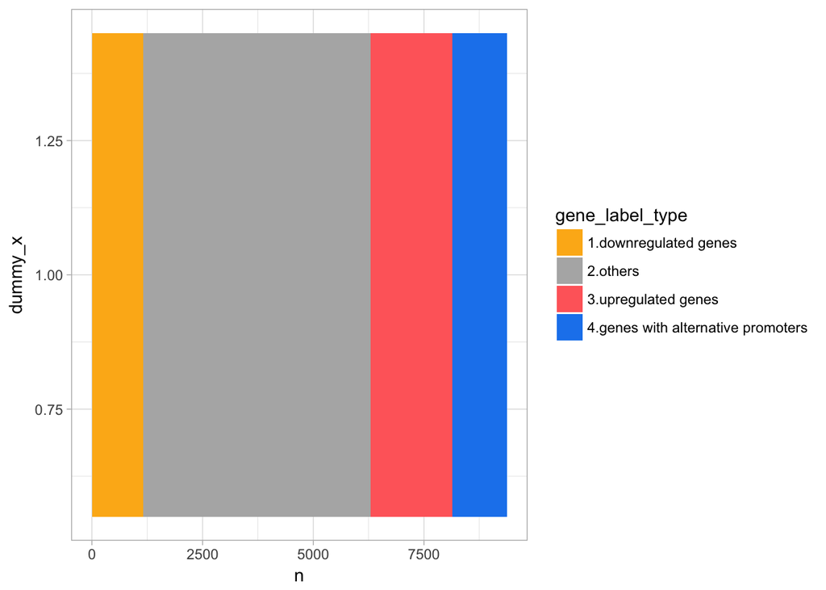

```r
kk2 %>% mutate(dummy_x=1) %>%  ggplot(aes(x = dummy_x, y = n, fill = gene_label_type)) + geom_bar(stat = "identity", position = position_stack(reverse = TRUE)) +
  scale_fill_manual(values = c("1.downregulated genes"=Bcc_gene_color, "2.others" ="grey70", "3.upregulated genes"=Hcc_g1_color, "4.genes with alternative promoters" =both_g2_color)) +
  coord_flip() + theme_light()
```

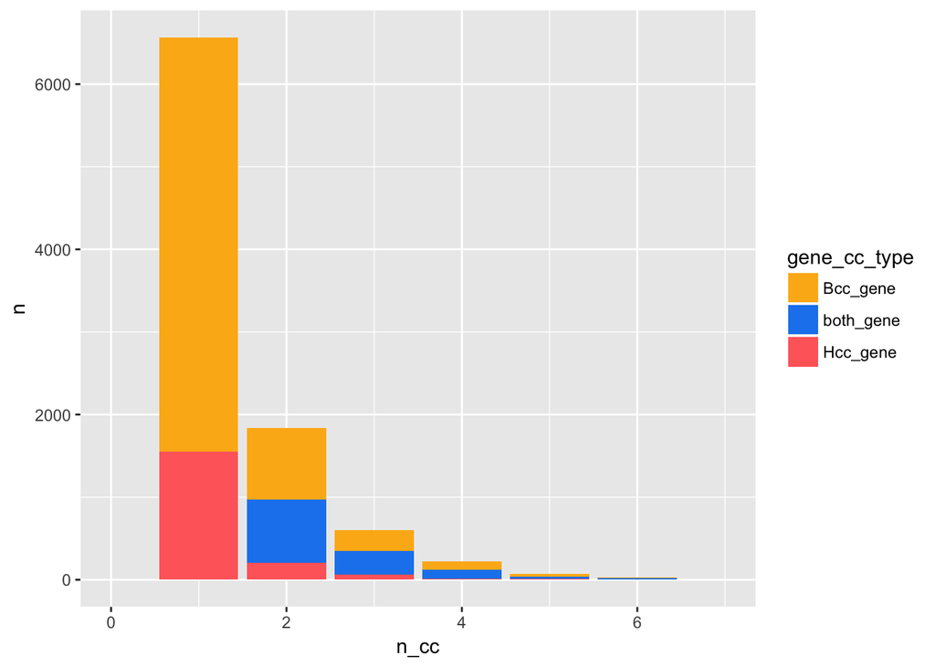

```r
ggsave("plot_gene_cc_type_count.pdf")
# plot by number of clusters per gene

cc_count %>%
  count(n_cc, gene_cc_type) %>%
  mutate(gene_cc_type = factor(gene_cc_type)) %>%
  ggplot(aes(x = n_cc, y = n, fill = gene_cc_type)) +
  geom_bar(stat = "identity") +
  scale_fill_manual(values = c("Bcc_gene"=Bcc_gene_color, "Hcc_gene"=Hcc_g1_color, "both_gene" =both_g2_color)) +   xlim(0,7)
```

# merge all labels into rlog_all

```r
nrow(rlog_all)
```

```
## [1] 13752
```

```r
rlog_all%<>%inner_join(cc_count, by=c("X"="X")) %>% mutate(n_cc = ifelse(is.na(n_cc), 0, n_cc))
nrow(rlog_all)
```

```
## [1] 13752
```

```r
rlog_all %<>% inner_join(allcc, by="V10") %>% mutate(cc_type = ifelse(is.na(cc_type), "neither", cc_type)) %>% mutate(is.shift = ifelse(is.na(is.shift), 0, is.shift))
nrow(rlog_all)
```

```
## [1] 13752
```

```r
table(complete.cases(rlog_all))
```

```
##
##  TRUE
## 13752
```

```r
rlog_all %<>% select(X, bam_RNA:Aly_RNA, V10, bam_CAGE, HS72_CAGE, gene_cc_type, n_cc, cc_type, is.shift)

write.table(rlog_all, "BDGP6_coding_up500_5utr_CDS_RNA_CAGE_rlog.txt", quote=F, sep="\t", row.names = F, col.names = T)
```

### scatter plot Bcc and Hcc

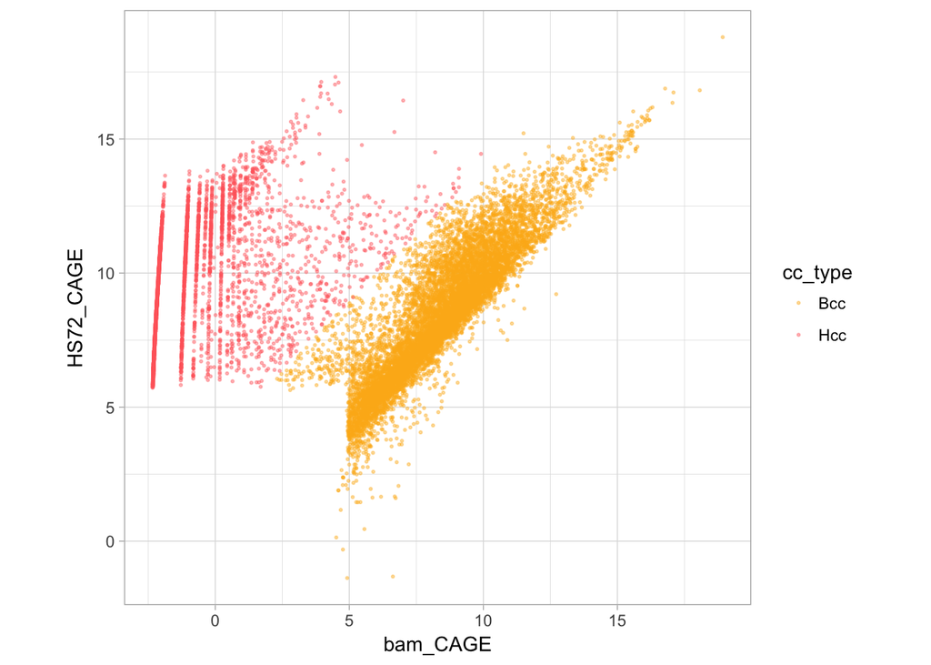

```r
rlog_all %>%  ggplot() + geom_point(aes(bam_CAGE, HS72_CAGE, color=cc_type), alpha = 4/10, size = 0.4) + scale_color_manual(values=c("Bcc"= Bcc_gene_color,"Hcc"= Hcc_g1_color)) + coord_fixed(ratio=1)  +
  theme_light()
```

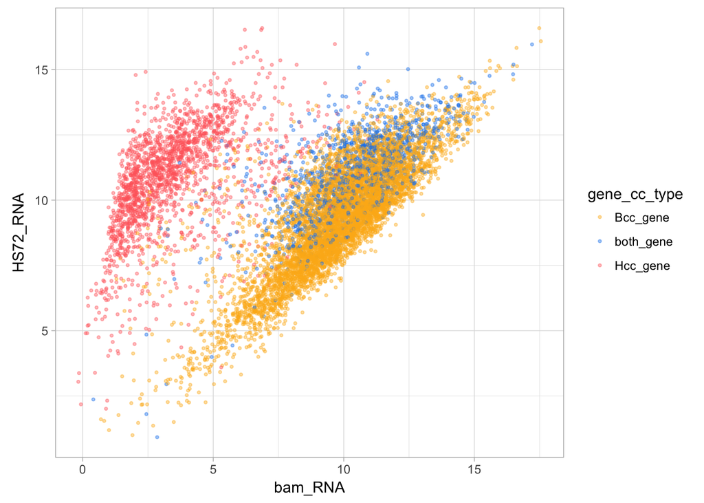

```r
rlog_all %>% select(X, bam_RNA, HS72_RNA, gene_cc_type) %>% unique() %>%  ggplot() + geom_point(aes(bam_RNA, HS72_RNA, color=gene_cc_type), alpha = 4/10, size = 0.7) + scale_color_manual(values = c("Bcc_gene"=Bcc_gene_color, "Hcc_gene"=Hcc_g1_color, "both_gene" =both_g2_color)) + coord_fixed(ratio=1) +
  theme_light()
```